# 🌍 Geospatial Land Coverage Analysis

Time Series Analysis of Land Use Changes - Democratic Republic of Congo

📅 2015 - 2023 📍 Eastern DRC (Kivu Region) 📊 9 Time Periods

## 📖 Introduction

This analysis examines land coverage changes in the Democratic Republic of Congo, specifically focusing on the eastern Kivu region. This area has experienced significant environmental changes due to various factors including agriculture expansion, urbanization, and resource extraction.

### Study Area Details

📄 Study Area Configuration ▶

```
# Define study area (Eastern DRC - Kivu region)
study_area = {
    'name': 'Eastern DRC (Kivu Region)',
    'bbox': {
        'north': -1.0,
        'south': -3.0,
        'east': 29.5,
        'west': 27.5
    },
    'center': [-2.0, 28.5]
}
```

## 📈 Summary Statistics

64.8%

Initial Forest Coverage (2015)

53.4%

Final Forest Coverage (2023)

-11.4%

Forest Change

11.4%

Urban Coverage (2023)

📄 Data Generation Function ▶

```
def generate_land_coverage_data(years, simulate_deforestation=True):
    """Generate simulated land coverage data showing realistic trends"""
    data = []

    # Initial percentages (sum to 100)
    initial_forest = 65.0
    initial_cropland = 20.0
    initial_urban = 5.0
    initial_water = 7.0
    initial_bare = 3.0

    for i, year in enumerate(years):
        if simulate_deforestation:
            forest = initial_forest - (i * 1.5) + np.random.normal(0, 0.5)
            urban = initial_urban + (i * 0.8) + np.random.normal(0, 0.3)
            cropland = initial_cropland + (i * 0.5) + np.random.normal(0, 0.4)
            # ... normalize and return DataFrame

    return pd.DataFrame(data)
```

## 📊 Land Coverage Trends

The visualizations below show the evolution of land coverage across different categories over the study period.

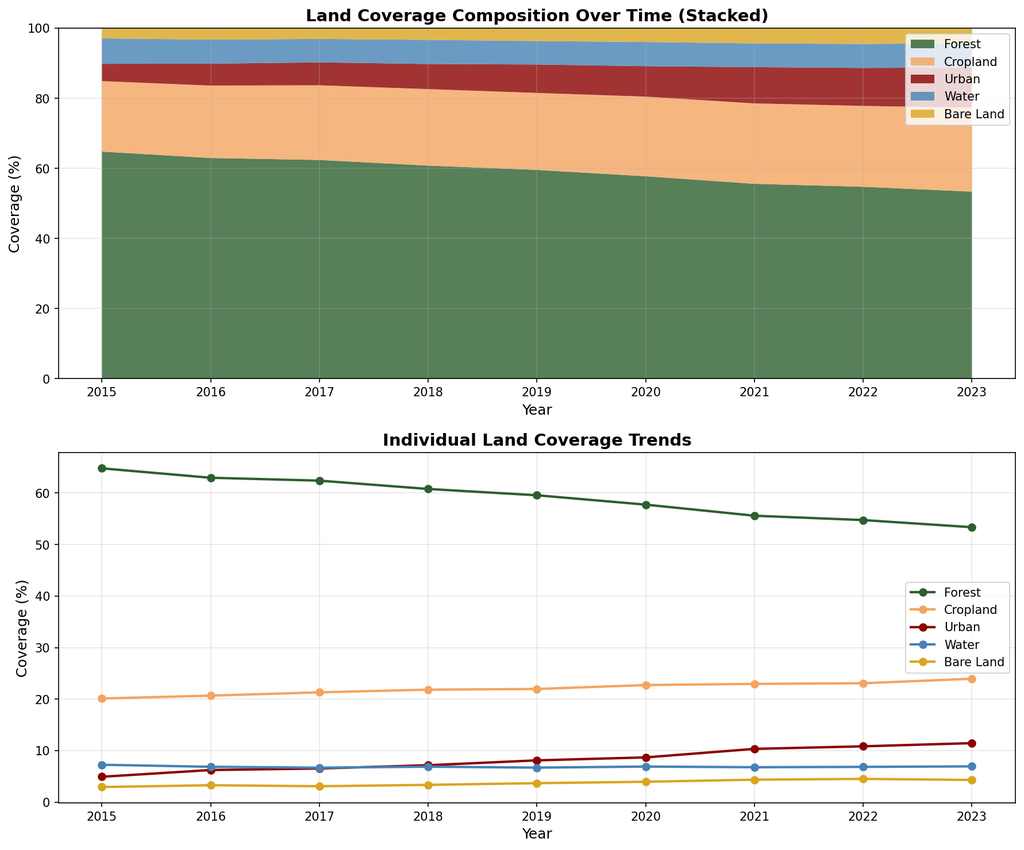

📄 Visualization Code ▶

```
import matplotlib.pyplot as plt

categories = ['Forest', 'Cropland', 'Urban', 'Water', 'Bare Land']
colors = ['#2d5f2e', '#f4a460', '#8b0000', '#4682b4', '#daa520']

fig, axes = plt.subplots(2, 1, figsize=(12, 10))

# Stacked area chart
axes[0].stackplot(land_coverage_df['Year'],
                  land_coverage_df['Forest'],
                  land_coverage_df['Cropland'],
                  land_coverage_df['Urban'],
                  land_coverage_df['Water'],
                  land_coverage_df['Bare Land'],
                  labels=categories, colors=colors, alpha=0.8)

# Individual trend lines
for category, color in zip(categories, colors):
    axes[1].plot(land_coverage_df['Year'], land_coverage_df[category],
                 marker='o', label=category, color=color, linewidth=2)
```

## 🗺️ Study Area Map

Interactive map showing the location of the study area in the Democratic Republic of Congo.

[interactive chart not shown]

📄 Map Generation Code ▶

```
import folium

# Create an interactive map
m = folium.Map(
    location=study_area['center'],
    zoom_start=8,
    tiles='OpenStreetMap'
)

# Add study area boundary
folium.Rectangle(
    bounds=[
        [study_area['bbox']['south'], study_area['bbox']['west']],
        [study_area['bbox']['north'], study_area['bbox']['east']]
    ],
    color='red',
    fill=True,
    fillOpacity=0.2,
    popup=f"Study Area: {study_area['name']}"
).add_to(m)
```

## 📋 Detailed Data

| Year | Forest (%) | Cropland (%) | Urban (%) | Water (%) | Bare Land (%) |
| --- | --- | --- | --- | --- | --- |
| 2015 | 64.78 | 20.11 | 4.92 | 7.25 | 2.93 |
| 2016 | 62.96 | 20.67 | 6.23 | 6.86 | 3.29 |
| 2017 | 62.39 | 21.31 | 6.53 | 6.68 | 3.09 |
| 2018 | 60.78 | 21.83 | 7.16 | 6.88 | 3.35 |
| 2019 | 59.56 | 21.96 | 8.11 | 6.70 | 3.68 |
| 2020 | 57.74 | 22.72 | 8.68 | 6.90 | 3.95 |
| 2021 | 55.59 | 22.95 | 10.33 | 6.77 | 4.36 |
| 2022 | 54.74 | 23.08 | 10.83 | 6.84 | 4.51 |
| 2023 | 53.36 | 23.95 | 11.45 | 6.94 | 4.30 |

📄 Data Processing Code ▶

```
import pandas as pd

# Create DataFrame with land coverage data
land_coverage_df = generate_land_coverage_data(years)

# Display summary statistics
print(land_coverage_df.describe().round(2))

# Calculate year-over-year changes
for col in categories:
    land_coverage_df[f'{col}_change'] = land_coverage_df[col].diff()
```

## 🔍 Key Findings

- **Forest Coverage:** Declined from 64.8% to 53.4% (change of -11.4 percentage points)
- **Urban Expansion:** Increased from 4.9% to 11.4% (change of 6.5 percentage points)
- **Agricultural Land:** Cropland coverage changed from 20.1% to 23.9%
- **Water Bodies:** Remained relatively stable at approximately 6.9%

### Implications for the DRC

The observed trends in the Eastern DRC region reflect broader environmental challenges:

- **Deforestation:** The decline in forest coverage is consistent with documented deforestation in the Congo Basin, driven by agricultural expansion and logging.
- **Urbanization:** Growing urban areas reflect population growth and migration patterns in the region.
- **Agricultural Pressure:** Increasing cropland suggests rising food production needs and potential conflicts between conservation and development.
- **Conservation Needs:** These trends highlight the importance of sustainable land management and conservation efforts in this biodiversity hotspot.

**Geospatial Land Coverage Analysis - Democratic Republic of Congo**

Generated on 2026-01-10

Data: Simulated for demonstration purposes. For production use, integrate real satellite data from Google Earth Engine or ESA WorldCover.